# Slave Voyages Code

Søren. L. F. Lageri

Created 28 May 2026, updated: 06. July 2026

```r
library(tidyverse)
library(dplyr)
library(ggplot2)
library(ggtext)
#sessionInfo()
```

The data was acquired from [The Trans-Atlantic Slave Trade Database](https://www.slavevoyages.org/).

The csv-files, which was used in this project, can be found here:

- https://www.slavevoyages.org/voyage/trans-atlantic#table
- https://www.slavevoyages.org/voyage/trans-atlantic#voyages

We combined both the embarked and disembarked csv-files into one csv-file with R.

```r
# We load the data and immediately add Spain and Portugal to Spain / Uruguay and Portugal / Brazil respectively.

Embarked_captives_data <- read_csv("../Project/Sum-of-embarked-captives-(IMP)-10-year-periods-with-Flag-(IMP)-fixed.csv")
Embarked_captives_data <- Embarked_captives_data %>%
  mutate(
    `Spain / Uruguay` =
      `Spain / Uruguay` + Spain,
    `Portugal / Brazil` =
      `Portugal / Brazil` + Portugal
  ) %>%
  select(
    -Spain,
    -Portugal
  )

Disembarked_captives_data <- read_csv("../Project/Sum-of-disembarked-captives-(IMP)-10-year-periods-with-Flag-(IMP)-fixed.csv")
Disembarked_captives_data <- Disembarked_captives_data %>%
  mutate(
    `Spain / Uruguay` =
      `Spain / Uruguay` + Spain,
    `Portugal / Brazil` =
      `Portugal / Brazil` + Portugal
  ) %>%
  select(
    -Spain,
    -Portugal
  )

Captives_data <- Embarked_captives_data %>%
  left_join(                         # We add the other dataset to the right (joins by left).
    Disembarked_captives_data,
    by = "Year range",               # They are joined up by year.
    suffix = c("_Embarked", "_Disembarked") #  and add the suffix to each coloumn name to be able to distinguish between them.
  )


Voyage_data <- read_csv("../Project/trans-atlantic-selected.csv")
```

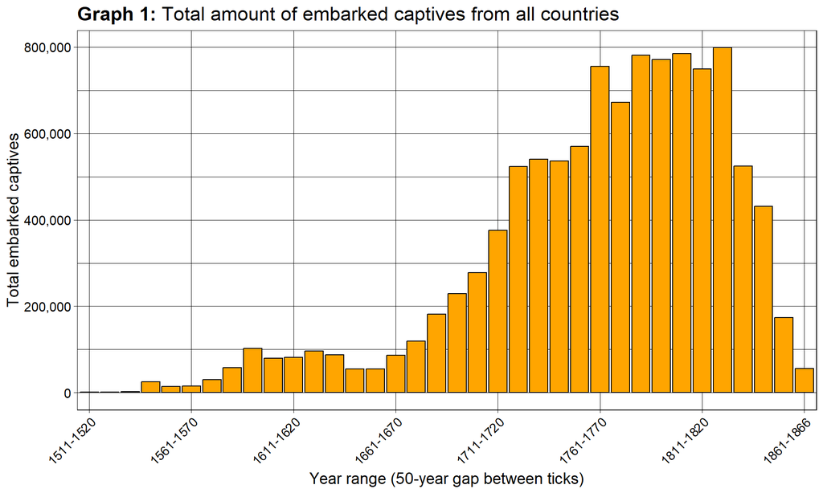

```r
Total_Embarked_plot <- ggplot(
  Captives_data %>% slice(1:36),
  aes(x = `Year range`, y = All_Embarked)
) +
  geom_col(color = "black", fill = "orange") +
  scale_y_continuous(labels = scales::label_comma()) +
  scale_x_discrete(
    breaks = Captives_data$`Year range`[1:36][seq(1, 36, by = 5)]
  ) +
  labs(
    title = "<b>Graph 1:</b> Total amount of embarked captives from all countries",
    x = "Year range (50-year gap between ticks)",
    y = "Total embarked captives"
  ) +
  theme_linedraw() +
  theme(
    plot.title = ggtext::element_markdown(),
    text = element_text(size = 14),
    axis.text.x = element_text(angle = 45, hjust = 1)
  )

Total_Embarked_plot
```

The total amount of captives who embarked throughout the Trans Atlantic Slave Trade was 10.643.518 or 10.64 million people.

### Now we look at the amount of captives who perished during the voyage

We can make a simple equation that involves taking the amount of embarked captives and subtracting it from the amount of disembarked captives.

$$\text{Perished captives}=\text{Embarked captives}-\text{Disembarked
captives}$$
Lastly, we can find how big a percentage the perished made out of the embarked captives with the following equation.

$$\text{Mortality rate percentage}=\frac{\text{Perished
captives}}{\text{Embarked captives}}\cdot100$$

The bodies of the captives who perished were most likely thrown in the ocean which would explain why the amount of disembarked captives was lower.

```r
Captives_data <- Captives_data %>%
  mutate(
    Perished = All_Embarked - All_Disembarked,
    Overall_mortality_rate_percentage = round((Perished / All_Embarked) * 100, 2))

Average_overall_mortality_percentage <- Captives_data %>%
  summarize(Average_mortality_percentage = mean(Overall_mortality_rate_percentage, na.rm = TRUE))
```

To create a stacked bar chart we need to separate the entire bar for one $x$-value into their own respective values.

i.e. we need to separate the values for the amount of captives who survived and how many perished.

```r
Perished_stacked <- Captives_data %>%
  slice(1:36) %>%   # Choose the first 37 rows
  mutate(
    Perished = All_Embarked - All_Disembarked,
    Mortality_rate_percentage = if_else(
      All_Embarked == 0,
      0,
      Perished / All_Embarked * 100)
    ) %>%
  transmute(
    `Year range`,
    Survived = All_Disembarked,  # We define survived and perished
    Perished = Perished
  ) %>%
  tidyr::pivot_longer(            # pivot_longer is used to increase the number of rows and decrease the number of columns.
    cols = c(Survived, Perished), # # We create two columns
    names_to = "Status",
    values_to = "Captives"
  )

# Prepare data for faceted plot
Facet_data <- bind_rows(
  Perished_stacked %>%
    mutate(Panel = "Outcome of embarked captives"),

  Perished_stacked %>%
    filter(Status == "Perished") %>%
    mutate(Panel = "Perished captives")
)
```

https://www.rdocumentation.org/packages/tidyr/versions/1.3.2/topics/pivot_longer

Now we are ready to make our stacked bar chart.

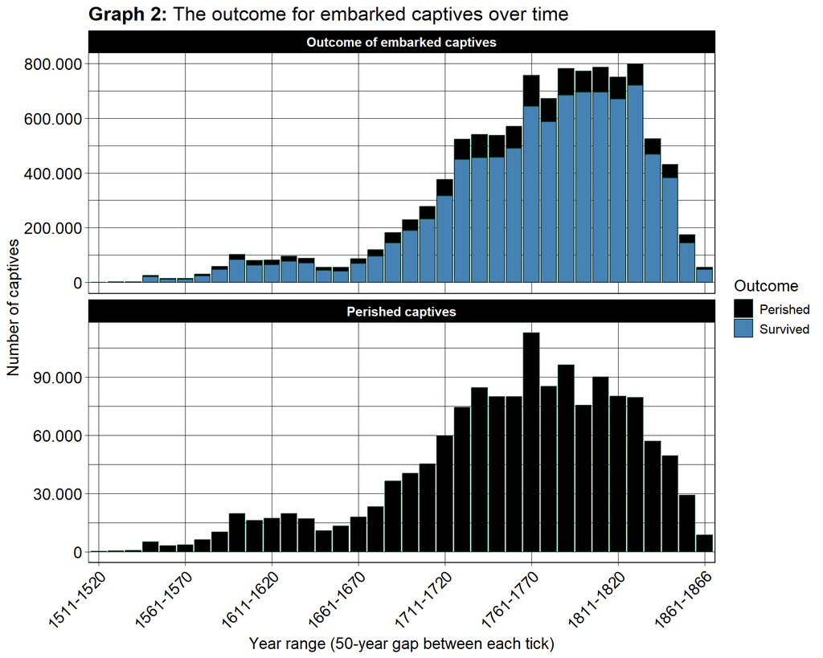

```r
# Create faceted plot
Tot_perished_captives_facet_plot <- ggplot(
  Facet_data,
  aes(x = `Year range`, y = Captives, fill = Status)
) +
  geom_col(color="#123524") +
  facet_wrap(~Panel, ncol = 1, scales = "free_y") +
  scale_fill_manual(
    values = c(
      "Survived" = "steelblue",
      "Perished" = "black"
    )
  ) +
  scale_y_continuous(labels = scales::label_number(big.mark = ".", decimal.mark = ",")
  ) +
  scale_x_discrete(breaks = Captives_data$`Year range`[1:36][seq(1, 36, by = 5)]
  ) +
  labs(
    title = "<b>Graph 2:</b> The outcome for embarked captives over time",
    x = "Year range (50-year gap between each tick)",
    y = "Number of captives",
    fill = "Outcome"
  ) +
  theme_linedraw() +
  theme(
    plot.title = ggtext::element_markdown(),
    text = element_text(size = 14),
    axis.text.x = element_text(angle = 45, hjust = 1, size = 14),
    axis.text.y = element_text(size = 14),
    strip.text = element_text(face = "bold")
  )

# Creating the mortality percentage plot
Mortality_percentage_plot <- ggplot(
  Captives_data %>% slice(1:36),
  aes(x = `Year range`, y = Overall_mortality_rate_percentage, group = 1)
) +
  geom_line(linewidth = 2, color = "red") +
  geom_point(size = 3, color = "black") +
  scale_y_continuous(
    labels = scales::label_number(suffix = "%")
  ) +
  scale_x_discrete(breaks = Captives_data$`Year range`[1:36][seq(1, 36, by = 5)]
  ) +
  labs(
    title = "<b>Graph 3:</b> Mortality rate of captives over time in percentage",
    x = "Year range (50-year gap between each tick)",
    y = "Mortality rate (%)"
  ) +
  theme_linedraw() +
  theme(
    plot.title = ggtext::element_markdown(),
    text = element_text(size = 14),
    axis.text.x = element_text(angle = 45, hjust = 1, size = 14),
    axis.text.y = element_text(size = 14)
  )

# Display plot
Tot_perished_captives_facet_plot
```

#### The corresponding mortality percentages.

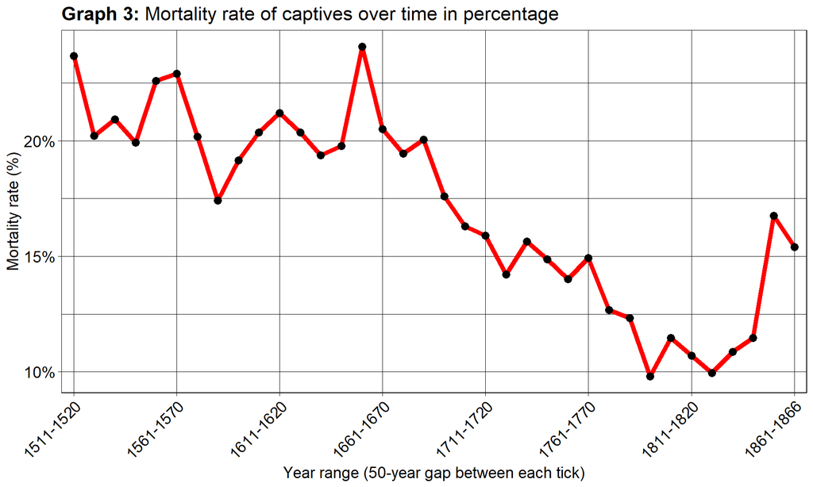

```r
Mortality_percentage_plot
```

Although the absolute number of deaths increased during periods of peak slave-trading activity, the mortality rate generally declined over time. This indicates that a smaller proportion of embarked captives died during the Middle Passage, even as the total number transported—and consequently the total number who perished—remained extremely high.

However, one thing that cannot be deducted from the plots is that even though the mortality rate was lowered, that does not mean the conditions onboard the ship were better. We know from sources, that the captives were packed very tightly in cramped spaces to maximize the amount of natives, which could be transported. (https://cdn.britannica.com/07/182907-050-C67CF42C/Detail-slave-ship-British-broadside-manner-children.jpg)

### Let us examine which country had the highest amount of captives who perished.

#### We will also find when each country abolished slavery.

```r
# We define a new data set. This will be used here to calculate the average and later.
Long_captives_data <- Captives_data %>%
  slice(1:36) %>%

  select(
    `Year range`,
    matches("_Embarked$|_Disembarked$")
  ) %>%

  select(-starts_with("All")) %>%
  pivot_longer(
    -`Year range`,
    names_to = c("Country", ".value"),
    names_pattern = "(.*)_(Embarked|Disembarked)"
  ) %>%

  mutate(
    Perished = Embarked - Disembarked,
    Mortality_rate_percentage = if_else(
      Embarked == 0,
      0,
      Perished / Embarked * 100
    )
  )

Long_captives_data
```

```
## # A tibble: 468 × 6
##    `Year range` Country     Embarked Disembarked Perished Mortality_rate_perce…¹
##    <chr>        <chr>          <dbl>       <dbl>    <dbl>                  <dbl>
##  1 1511-1520    Austria            0           0        0                    0
##  2 1511-1520    Bremen             0           0        0                    0
##  3 1511-1520    Denmark / …        0           0        0                    0
##  4 1511-1520    Duchy of C…        0           0        0                    0
##  5 1511-1520    France             0           0        0                    0
##  6 1511-1520    Great Brit…        0           0        0                    0
##  7 1511-1520    Netherlands        0           0        0                    0
##  8 1511-1520    Other              0           0        0                    0
##  9 1511-1520    Portugal /…      624         464      160                   25.6
## 10 1511-1520    Spain / Ur…      144         109       35                   24.3
## # ℹ 458 more rows
## # ℹ abbreviated name: ¹Mortality_rate_percentage
```

```r
Average_mortality_percentage <- Long_captives_data %>%
  filter(Mortality_rate_percentage != 0) %>%
  summarize(
    Average_mortality_percentage =
      mean(Mortality_rate_percentage, na.rm = TRUE)
  )

Average_mortality_percentage
```

```
## # A tibble: 1 × 1
##   Average_mortality_percentage
##                          <dbl>
## 1                         16.3
```

```r
# Abolition of slavery for each country

abolition_years <- tibble::tribble(
  ~Country, ~abolished_slavery_year,
  "Portugal / Brazil", 1836,
  "Great Britain", 1807,
  "France", 1817,
  "Spain / Uruguay", 1817
)

Perished_by_country <- Captives_data %>%
  slice(1:36) %>%
  select(matches("_Embarked$|_Disembarked$")) %>%
  select(-starts_with("All")) %>%

  pivot_longer(
    everything(),
    names_to = c("Country", ".value"),
    names_pattern = "(.*)_(Embarked|Disembarked)"
  ) %>%

  mutate(
    Perished = Embarked - Disembarked
  ) %>%

  group_by(Country) %>%
  summarise(
    Total_perished = sum(Perished, na.rm = TRUE),
    .groups = "drop"
  ) %>%

  left_join(abolition_years, by = "Country") %>%

  arrange(desc(Total_perished))

Perished_by_country
```

```
## # A tibble: 13 × 3
##    Country           Total_perished abolished_slavery_year
##    <chr>                      <dbl>                  <dbl>
##  1 Great Britain             484619                   1807
##  2 Portugal / Brazil         413574                   1836
##  3 France                    190208                   1817
##  4 Undefined                 120744                     NA
##  5 Netherlands                84738                     NA
##  6 Spain / Uruguay            70893                   1817
##  7 Denmark / Baltic           17677                     NA
##  8 Other                        531                     NA
##  9 Austria                      492                     NA
## 10 Duchy of Courland            111                     NA
## 11 Bremen                        53                     NA
## 12 Sweden                        15                     NA
## 13 U.S.A.                         0                     NA
```

```r
Perished_by_country[1:6,]
```

```
## # A tibble: 6 × 3
##   Country           Total_perished abolished_slavery_year
##   <chr>                      <dbl>                  <dbl>
## 1 Great Britain             484619                   1807
## 2 Portugal / Brazil         413574                   1836
## 3 France                    190208                   1817
## 4 Undefined                 120744                     NA
## 5 Netherlands                84738                     NA
## 6 Spain / Uruguay            70893                   1817
```

We decided to focus on Great Britain, Portugal / Brazil, France, and Spain / Uruguay. Since we cannot conclude anything from the Country labeled as Undefined, will they be excluded from the following plots.

### Looking at the individual countries mortality rate

```r
# Chosen countries we want to examine
Chosen_countries <- c(
  "Portugal / Brazil",
  "Great Britain",
  "France",
  "Spain / Uruguay"
)

# Creating a country dataset
Country_data <- Captives_data %>%
  slice(1:36) %>%
  select(
    `Year range`,
    matches("_Embarked$|_Disembarked$")
  ) %>%
  select(-starts_with("All")) %>%
  pivot_longer(
    -`Year range`,
    names_to = c("Country", ".value"),
    names_pattern =
      "(.*)_(Embarked|Disembarked)"
  ) %>%

  filter(
    Country %in% Chosen_countries
  ) %>%

  mutate(
  Perished = Embarked - Disembarked,

  Mortality_rate_percentage =
    replace(
      Perished / Embarked * 100,
      is.nan(Perished / Embarked * 100),
      0
    )
)

# Preparing the facet data
Facet_plot_countries <- bind_rows(

  # Outcome plot
  Country_data %>%
    select(
      `Year range`,
      Country,
      Survived = Disembarked,
      Perished
    ) %>%
    pivot_longer(
      cols = c(Survived, Perished),
      names_to = "Status",
      values_to = "Value"
    ) %>%
    mutate(
      Panel = "Outcome of embarked captives"
    ),

  # Perished captives
  Country_data %>%
    transmute(
      `Year range`,
      Country,
      Status = "Perished",
      Value = Perished,
      Panel = "Perished captives"
    ),

  # Mortality rate
  Country_data %>%
    transmute(
      `Year range`,
      Country,
      Status = "Mortality rate",
      Value = Mortality_rate_percentage,
      Panel = "Mortality rate percentage"
    )
)


abolition_lines <- abolition_years %>%

  mutate(

    Year_range_position = sapply(
      abolished_slavery_year,
      function(year) {

        unique(Facet_plot_countries$`Year range`)[
          sapply(
            strsplit(unique(Facet_plot_countries$`Year range`), "-"),
            function(rng) {

              lower <- as.numeric(rng[1])
              upper <- as.numeric(rng[2])

              year >= lower & year <= upper
            }
          )
        ]
      }
    ),

    x_position =
      match(
        Year_range_position,
        unique(Facet_plot_countries$`Year range`)
      ),

    label = paste0(
      "Abolished\n",
      abolished_slavery_year
    )
  )
```

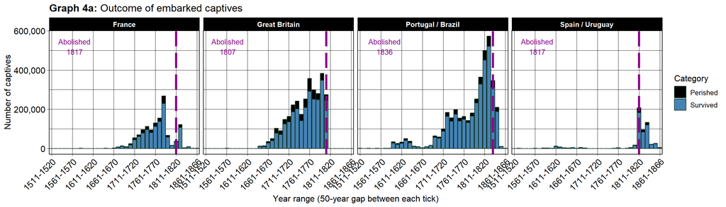

```r
AxisText_SizeAll = 12

Outcome_plot <- Facet_plot_countries %>%
  filter(Panel == "Outcome of embarked captives") %>%

ggplot(
  aes(x = `Year range`, y = Value, fill = Status)
) +
  geom_col(color = "#123524") +
  facet_wrap(~Country, nrow = 1) +
  scale_fill_manual(
    values = c(
      "Survived" = "steelblue",
      "Perished" = "black"
    )
  ) +
  geom_vline(
  data = abolition_lines,
  aes(xintercept = x_position),
  linetype = "longdash",
  linewidth = 1.5,
  color = "darkmagenta",
  inherit.aes = FALSE
) +

geom_text(
  data = abolition_lines,
  aes(
    x = x_position*0.21,
    y = Inf,
    label = label
  ),
  vjust = 1.5,
  color = "darkmagenta",
  size = 3.5,
  inherit.aes = FALSE
) +
  scale_x_discrete(
    breaks =
      Captives_data$`Year range`[1:36][seq(1, 36, by = 5)]
  ) +

  scale_y_continuous(
    labels = scales::label_comma()
  ) +

  labs(
    title = "<b>Graph 4a:</b> Outcome of embarked captives",
    x = "Year range (50-year gap between each tick)",
    y = "Number of captives",
    fill = "Category"
  ) +
  coord_cartesian(clip = "off") +
  theme_linedraw() +
  theme(
    plot.title = ggtext::element_markdown(),
    text = element_text(size = AxisText_SizeAll),
    axis.text.x = element_text(angle = 45, hjust = 1,size=AxisText_SizeAll),
    axis.text.y = element_text(size=AxisText_SizeAll),
    strip.text = element_text(face = "bold")
  )
Outcome_plot
```

```r
ggsave("Graphs/4.a.Chosen_countries.png", width=14, height=4)
```

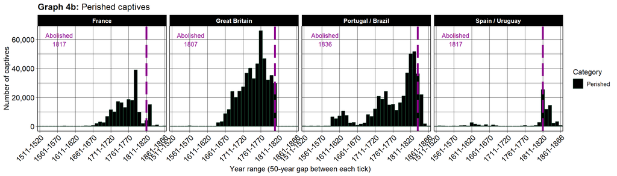

```r
Perished_plot <- Facet_plot_countries %>%
  filter(Panel == "Perished captives") %>%

ggplot(
  aes(x = `Year range`, y = Value, fill = Status)
) +
  geom_col(color = "#123524") +

  facet_wrap(~Country, nrow = 1) +

  scale_fill_manual(
    values = c("Perished" = "black")
  ) +

  scale_x_discrete(
    breaks =
      Captives_data$`Year range`[1:36][seq(1, 36, by = 5)]
  ) +

  scale_y_continuous(
    labels = scales::label_comma()
  ) +

  labs(
    title = "<b>Graph 4b:</b> Perished captives",
    x = "Year range (50-year gap between each tick)",
    y = "Number of captives",
    fill = "Category"
  ) +
    geom_vline(
  data = abolition_lines,
  aes(xintercept = x_position),
  linetype = "longdash",
  linewidth = 1.5,
  color = "darkmagenta",
  inherit.aes = FALSE
) +

geom_text(
  data = abolition_lines,
  aes(
    x = x_position*0.21,
    y = Inf,
    label = label
  ),
  vjust = 1.5,
  color = "darkmagenta",
  size = 3.5,
  inherit.aes = FALSE
) +
  coord_cartesian(clip = "off") +
  theme_linedraw() +
  theme(
    plot.title = ggtext::element_markdown(),
    text = element_text(size = AxisText_SizeAll),
    axis.text.x = element_text(angle = 45, hjust = 1,size=AxisText_SizeAll),
    axis.text.y = element_text(size=AxisText_SizeAll),
    strip.text = element_text(face = "bold")
  )
Perished_plot
```

```r
ggsave("Graphs/4.b.Chosen_countries.png", width=14, height=4)
```

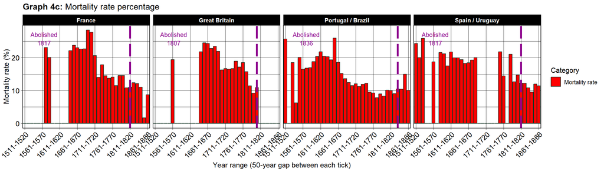

```r
Mortality_plot <- Facet_plot_countries %>%
  filter(Panel == "Mortality rate percentage") %>%

ggplot(
  aes(x = `Year range`, y = Value, fill = Status)
) +
  geom_col(color = "#123524") +

  facet_wrap(~Country, nrow = 1) +

  scale_fill_manual(
    values = c("Mortality rate" = "red")
  ) +

  scale_x_discrete(
    breaks =
      Captives_data$`Year range`[1:36][seq(1, 36, by = 5)]
  ) +

  labs(
    title = "<b>Graph 4c:</b> Mortality rate percentage",
    x = "Year range (50-year gap between each tick)",
    y = "Mortality rate (%)",
    fill = "Category"
  ) +
    geom_vline(
  data = abolition_lines,
  aes(xintercept = x_position),
  linetype = "longdash",
  linewidth = 1.5,
  color = "darkmagenta",
  inherit.aes = FALSE
) +

geom_text(
  data = abolition_lines,
  aes(
    x = x_position*0.21,
    y = Inf,
    label = label
  ),
  vjust = 1.5,
  color = "darkmagenta",
  size = 3.5,
  inherit.aes = FALSE
) +
  coord_cartesian(clip = "off") +
  theme_linedraw() +
  theme(
    plot.title = ggtext::element_markdown(),
    text = element_text(size = AxisText_SizeAll),
    axis.text.x = element_text(angle = 45, hjust = 1,size=AxisText_SizeAll),
    axis.text.y = element_text(size=AxisText_SizeAll),
    strip.text = element_text(face = "bold")
  )
Mortality_plot
```

```r
ggsave("Graphs/4.c.Chosen_countries.png", width=14, height=4)
```

### Lastly, we look at the tonnage of the ships.

We think there will be a lineary coalation between the tonnage of the ship and the amount of captives who perished on the ship.

```r
Chosen_countries_2 <- c(
  "Portugal / Brazil",
  "Portugal",
  "Great Britain",
  "France",
  "Spain / Uruguay",
  "Spain"
)

Voyage_data_tonnage <- Voyage_data %>%
  select(`Year arrived with captives`,`Total disembarked (IMP)`,`Total embarked (IMP)`,`Standardized Tonnage (IMP)`,`Flag of vessel (IMP)`) %>%
  mutate(`Perished` = `Total embarked (IMP)`-`Total disembarked (IMP)`,
         Mortality_rate = round(`Perished` / `Total embarked (IMP)` * 100,2)) %>%
  arrange(desc(`Standardized Tonnage (IMP)`))

Tonnage_summary <- Voyage_data %>%
  select(
    `Standardized Tonnage (IMP)`,
    `Flag of vessel (IMP)`
  ) %>%
  filter(`Flag of vessel (IMP)` %in% Chosen_countries_2) %>%
  mutate(
    `Flag of vessel (IMP)` = case_when(
      `Flag of vessel (IMP)` == "Portugal" ~ "Portugal / Brazil",
      `Flag of vessel (IMP)` == "Spain" ~ "Spain / Uruguay",
      TRUE ~ `Flag of vessel (IMP)`
    )
  ) %>%
  filter(`Standardized Tonnage (IMP)` > 0) %>%
  group_by(`Flag of vessel (IMP)`) %>%
  summarise(
    Voyages = n(),
    Average_tonnage = round(mean(`Standardized Tonnage (IMP)`, na.rm = TRUE), 1),
    .groups = "drop"
  ) %>%
  arrange(desc(Voyages))

Tonnage_summary
```

```
## # A tibble: 4 × 3
##   `Flag of vessel (IMP)` Voyages Average_tonnage
##   <chr>                    <int>           <dbl>
## 1 Great Britain             9774            190.
## 2 France                    2823            230.
## 3 Portugal / Brazil         1665            165.
## 4 Spain / Uruguay            311            183.
```

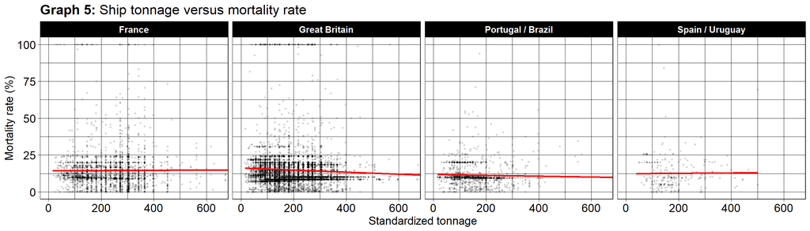

```r
Tonnage_VS_mortality_rate_plot <- Voyage_data_tonnage %>%
  filter(`Flag of vessel (IMP)` %in% Chosen_countries_2) %>%
  mutate(
    `Flag of vessel (IMP)` = case_when(
      `Flag of vessel (IMP)` == "Portugal" ~ "Portugal / Brazil",
      `Flag of vessel (IMP)` == "Spain" ~ "Spain / Uruguay",
      TRUE ~ `Flag of vessel (IMP)`
    )
  ) %>%
  filter(
    `Standardized Tonnage (IMP)` > 0,
    between(Mortality_rate, 0, 100)
  ) %>%
  ggplot(aes(
    x = `Standardized Tonnage (IMP)`,
    y = Mortality_rate
  )) +
  geom_point(alpha = 0.15, size = 0.8) +
  geom_smooth(method = "lm", se = FALSE, color = "red") +
  facet_wrap(~`Flag of vessel (IMP)`, nrow = 1 )+#, scales = "free") +
  coord_cartesian(xlim = c(0, 650)) + # Since 38 voyages exceed a ship tonnage of 600 we ignore these but do not remove them.
  labs(
    title = "<b>Graph 5:</b> Ship tonnage versus mortality rate",
    #subtitle = "Comparison of the four largest slave-trading nations",
    x = "Standardized tonnage",
    y = "Mortality rate (%)"
  ) +
  theme_linedraw() +
  theme(
    plot.title = ggtext::element_markdown(),
    text = element_text(size = AxisText_SizeAll+2),
    strip.text = element_text(face = "bold"),
    axis.text.x = element_text(size = AxisText_SizeAll+2),
    axis.text.y = element_text(size = AxisText_SizeAll+2)
  )
Tonnage_VS_mortality_rate_plot
```

```r
ggsave("Graphs/TonnageVSmortalityrate.png", width=14, height=4)
```

The graph shows the relationship between standardized ship tonnage and mortality rate for the four largest slave-trading nations. The fitted linear regression lines are nearly horizontal in all four panels, indicating little to no linear relationship between ship size and mortality rate. While mortality rates vary considerably between voyages, larger ships do not appear to have systematically higher or lower mortality rates than smaller ships.

Therefore, Within this dataset, no strong association between standardized ship tonnage and mortality rate is observed.

One thing that stands out much more than the trend is the horizontal line of points at 100% mortality. Those correspond to voyages where:

Embarked > 0 Disembarked = 0

While possible for a handful of voyages, there seem to be too many of them. They may represent voyages that were abandoned, missing data, or records where no disembarkation was recorded.

We can check how many there are with:

```r
Voyage_data_tonnage %>%
  filter(
    `Standardized Tonnage (IMP)` > 0,
    Mortality_rate == 100
  ) %>%
  count(`Flag of vessel (IMP)`)
```

```
## # A tibble: 4 × 2
##   `Flag of vessel (IMP)`     n
##   <chr>                  <int>
## 1 France                    33
## 2 Great Britain            122
## 3 Netherlands                2
## 4 U.S.A.                     1
```

Finding voyages which had a ship tonnage size greater than 600.

```r
Voyage_data_tonnage %>%
  filter(`Standardized Tonnage (IMP)` > 600) %>%
  summarise(Total_voyages = n())
```

```
## # A tibble: 1 × 1
##   Total_voyages
##           <int>
## 1            38
```

38 voyages had a ship tonnage size greater than 600.

### Average ship tonnage size throughout the period

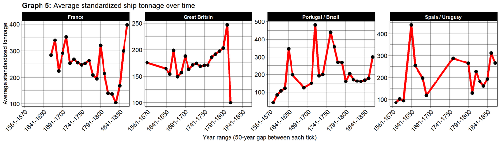

```r
Chosen_countries <- c(
  "Portugal / Brazil",
  "Great Britain",
  "France",
  "Spain / Uruguay"
)

Average_tonnage <- Voyage_data %>%
  filter(`Flag of vessel (IMP)` %in% Chosen_countries_2) %>%
  mutate(
    `Flag of vessel (IMP)` = case_when(
      `Flag of vessel (IMP)` == "Portugal" ~ "Portugal / Brazil",
      `Flag of vessel (IMP)` == "Spain" ~ "Spain / Uruguay",
      TRUE ~ `Flag of vessel (IMP)`
    )
  ) %>%
  filter(`Standardized Tonnage (IMP)` > 0) %>%
  mutate(
    Start_year = ((`Year arrived with captives` - 1511) %/% 10) * 10 + 1511,
    `Year range` = paste0(
      Start_year,
      "-",
      pmin(Start_year + 9, 1866)
    )
  ) %>%
  group_by(`Flag of vessel (IMP)`, Start_year, `Year range`) %>%
  summarise(
    Average_tonnage = mean(`Standardized Tonnage (IMP)`, na.rm = TRUE),
    .groups = "drop"
  ) %>%
  arrange(Start_year) %>%
  mutate(
    `Year range` = factor(
      `Year range`,
      levels = unique(`Year range`)
    )
  )

Average_tonnage_plot <- ggplot(
  Average_tonnage,
  aes(
    x = `Year range`,
    y = Average_tonnage,
    group = `Flag of vessel (IMP)`
  )
) +
  geom_line(linewidth = 2, color = "red") +
  geom_point(size = 3, color = "black") +
  facet_wrap(~`Flag of vessel (IMP)`, nrow = 1, scales = "free_y") +
  scale_x_discrete(
    breaks = levels(Average_tonnage$`Year range`)[
      seq(1, length(levels(Average_tonnage$`Year range`)), by = 5)
    ]
  ) +
  labs(
    title = "<b>Graph 5:</b> Average standardized ship tonnage over time",
    x = "Year range (50-year gap between each tick)",
    y = "Average standardized tonnage"
  ) +
  theme_linedraw() +
  coord_cartesian(clip = "off") +
  theme(
    plot.title = ggtext::element_markdown(),
    text = element_text(size = AxisText_SizeAll),
    axis.text.x = element_text(angle = 45, hjust = 1,size=AxisText_SizeAll),
    axis.text.y = element_text(size=AxisText_SizeAll),
    strip.text = element_text(face = "bold")
  )

Average_tonnage_plot
```

```r
ggsave("Graphs/Average_tonnage_plot.png", width=14, height=4)
```